# Color Palettes in R

TF

2018-07-22

Colors, amirite? Finding the right ones to make a plot look good can be hard. I always like to use colors that really help set my plots apart. `tidyverse` and `ggplot` in particular are great at incorporating wonderful palettes. However, recently I was vexed by a plot where I couldnt just use a theme addition to add the colors I wanted and instead had to specify each color I wanted. At the time I wanted to use something from the `ggsci` package but coudlnt find the names or hex codes for the color. This post is meant to be a reference for myself and others on the different hex codes for packages.

#libraries

```r
library(tidyverse)
library(scales)
library(RColorBrewer)
library(ggsci)
library(wesanderson)
library(ggthemes)
```

#ggsci colors and Hex (not a complete list)

JAMA

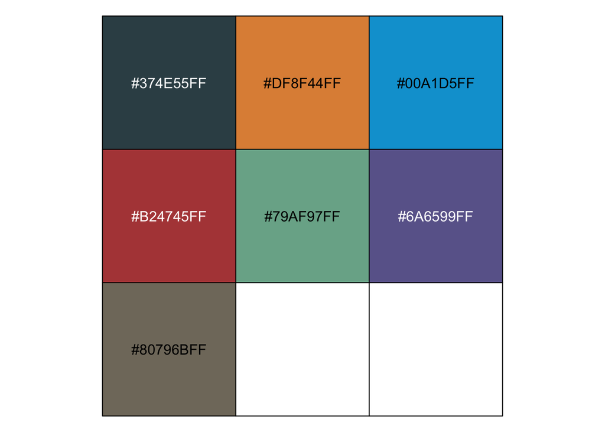

```r
show_col(pal_jama("default")(7))
```

NEJM

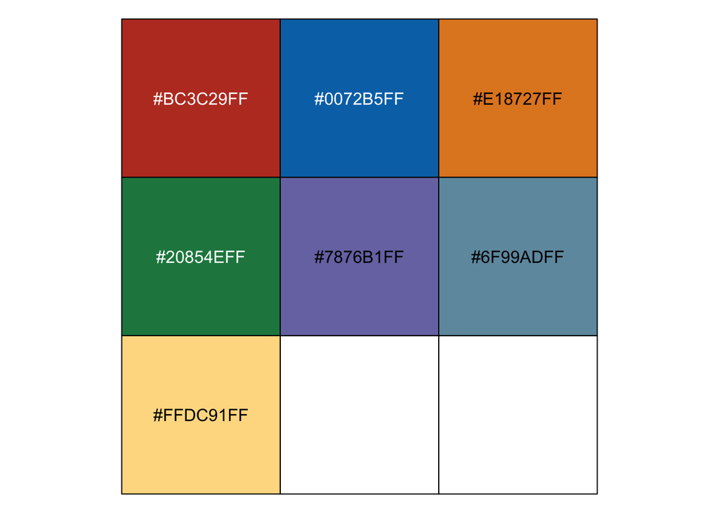

```r
show_col(pal_nejm("default")(7))
```

nature publishing group

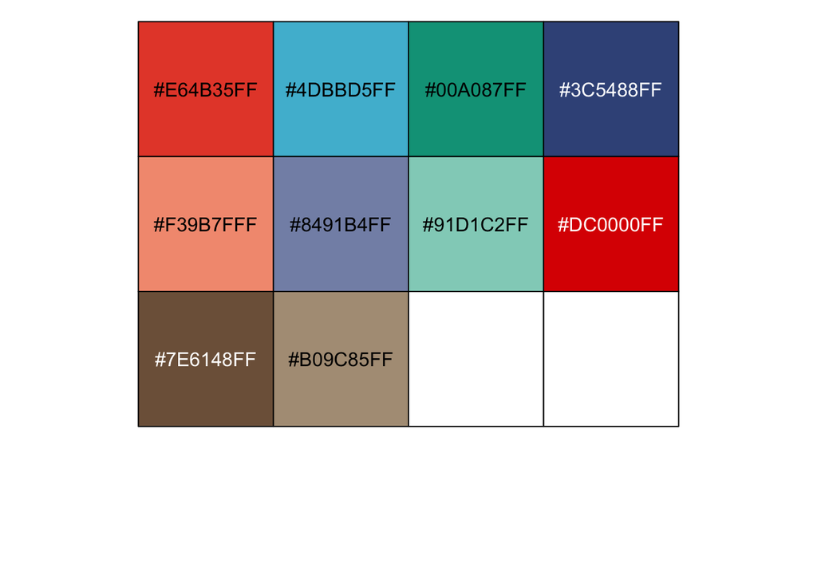

```r
show_col(pal_npg("nrc")(10))
```

Univof Chicago

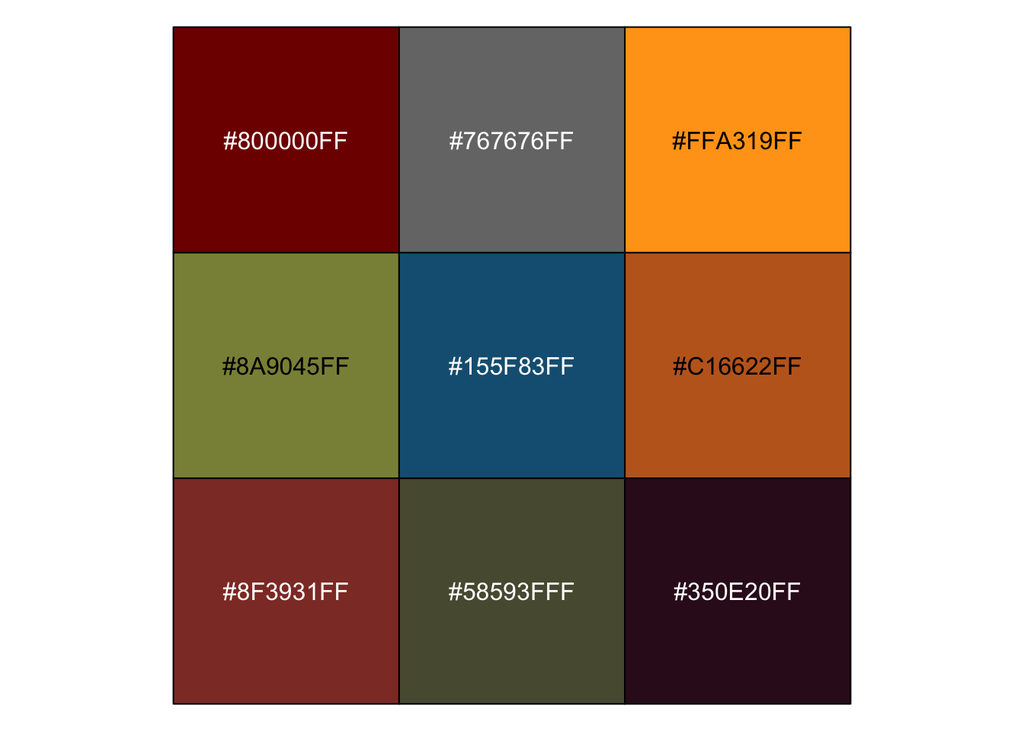

```r
show_col(pal_uchicago("default")(9))
```

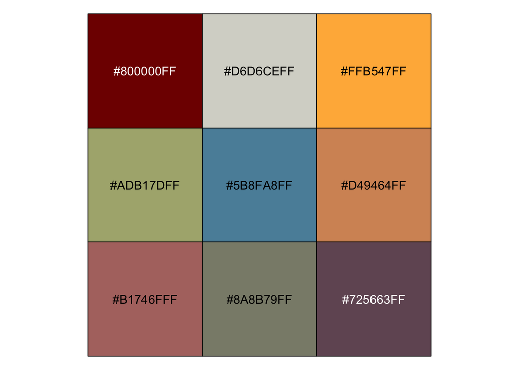

```r
    show_col(pal_uchicago("light")(9))
```

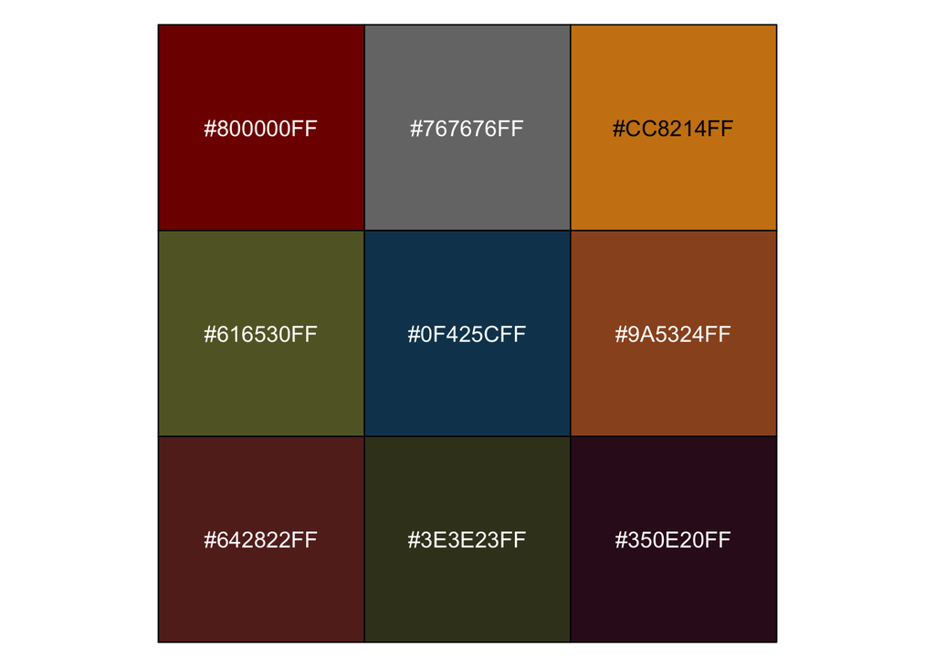

```r
    show_col(pal_uchicago("dark")(9))
```

J of Clin Oncology

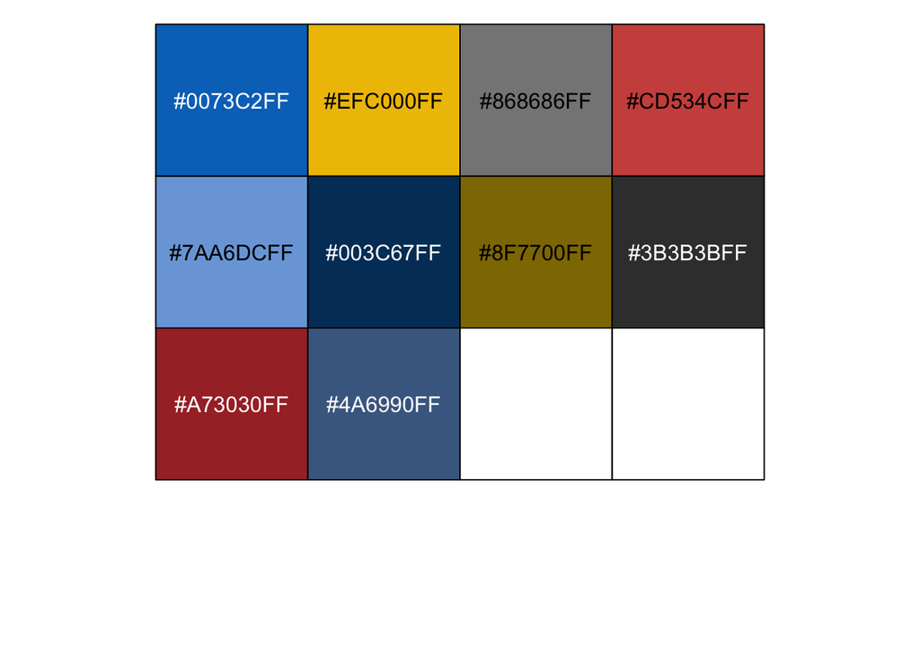

```r
show_col(pal_jco("default")(10))
```

Lancet

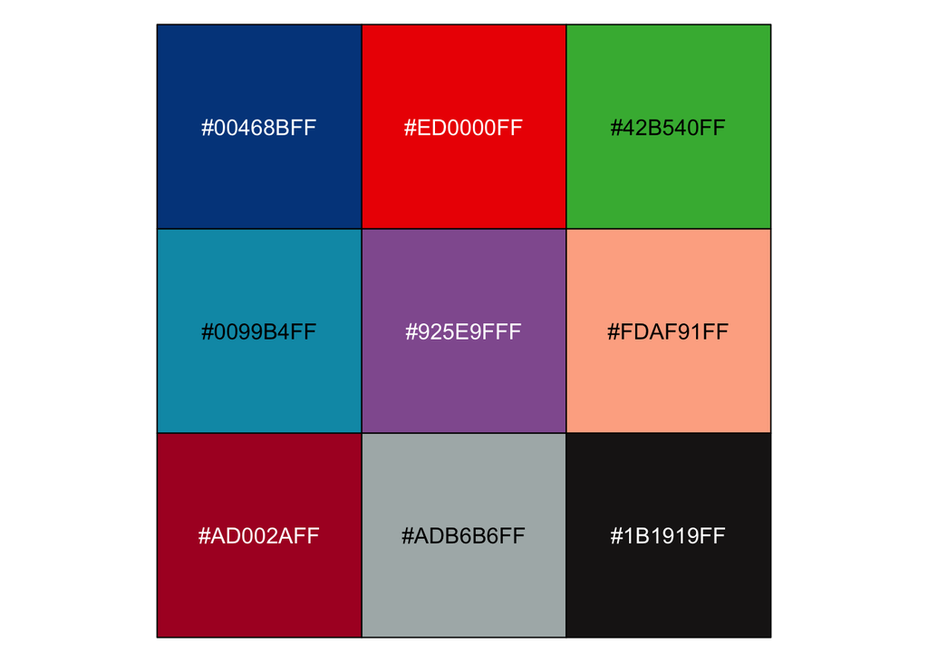

```r
show_col(pal_lancet("lanonc")(9))
```

Star Trek

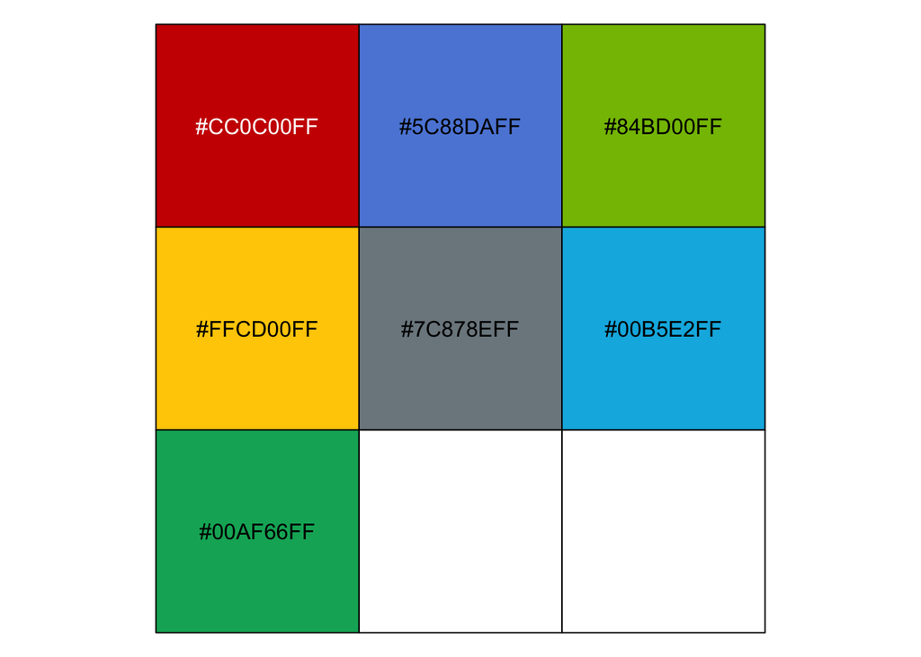

```r
show_col(pal_startrek("uniform")(7))
```

Simpsons

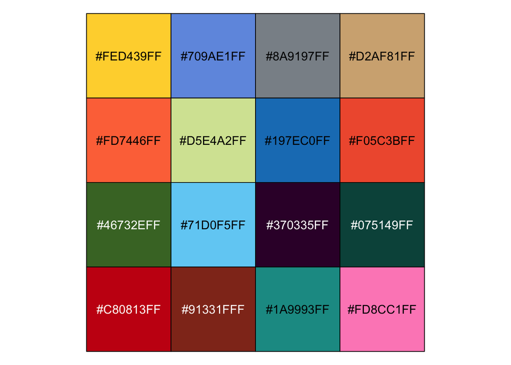

```r
show_col(pal_simpsons("springfield")(16))
```

Rick and Morty

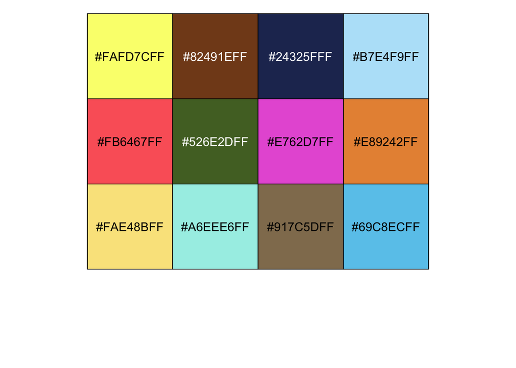

```r
show_col(pal_rickandmorty("schwifty")(12))
```

#ggthemes colors Stata

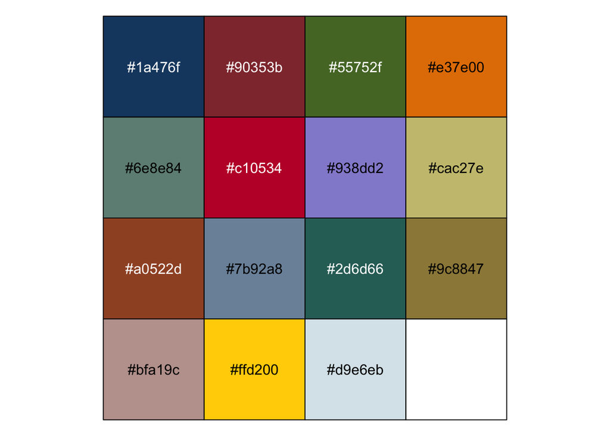

```r
show_col(stata_pal("s2color")(15))
```

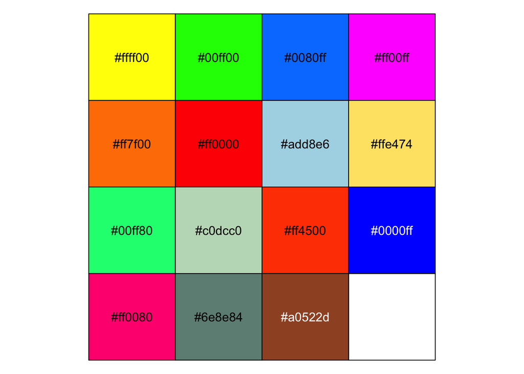

```r
    show_col(stata_pal("s1rcolor")(15))
```

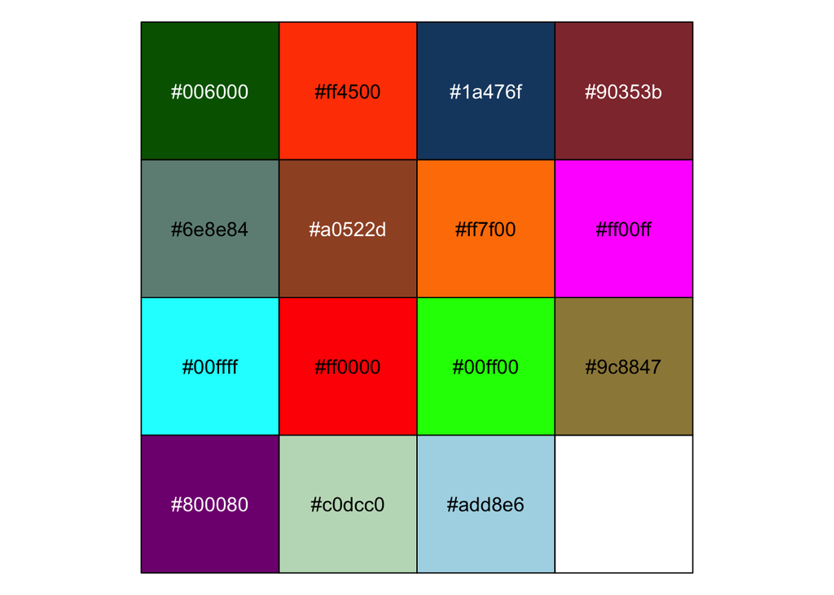

```r
    show_col(stata_pal("s1color")(15))
```

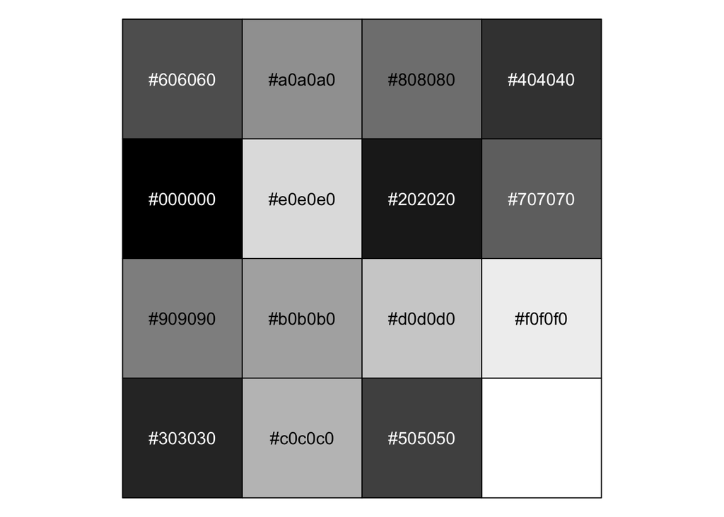

```r
    show_col(stata_pal("mono")(15))
```

538 theme colors

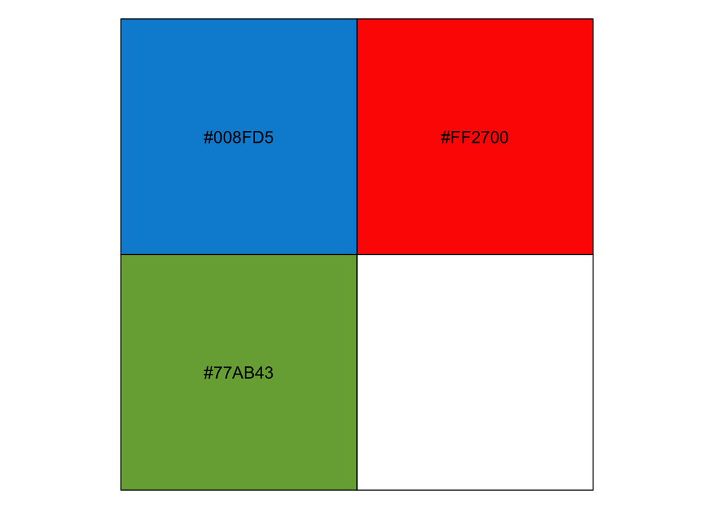

```r
show_col(fivethirtyeight_pal()(3))
```

google docs colors

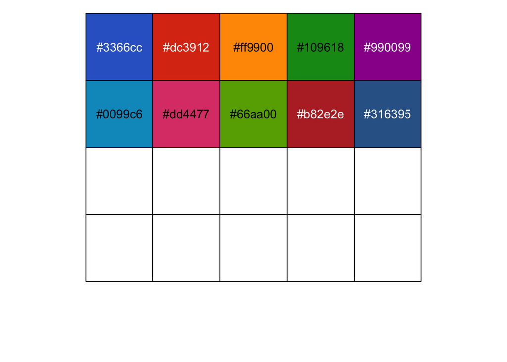

```r
show_col(gdocs_pal()(20))
```

economist

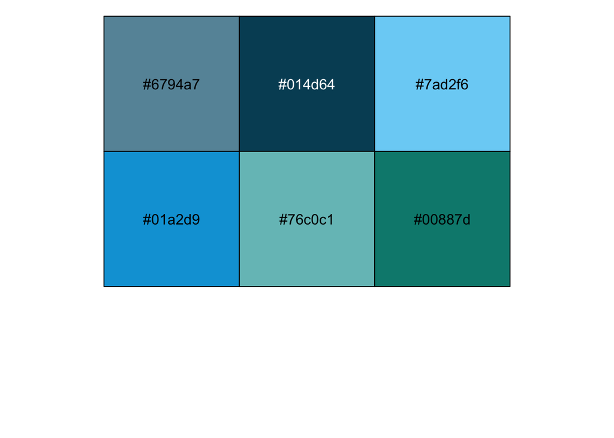

```r
show_col(economist_pal()(6))
    ## fill palette
    show_col(economist_pal(fill = TRUE)(6))
```

[output not shown]

colorblind

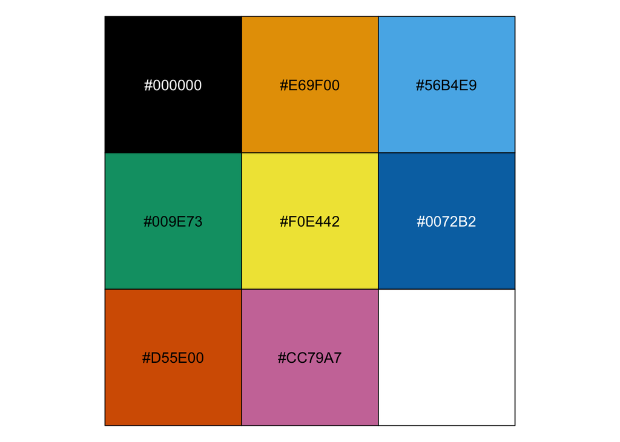

```r
show_col(colorblind_pal()(8))
```

#Display overall Brewer colors

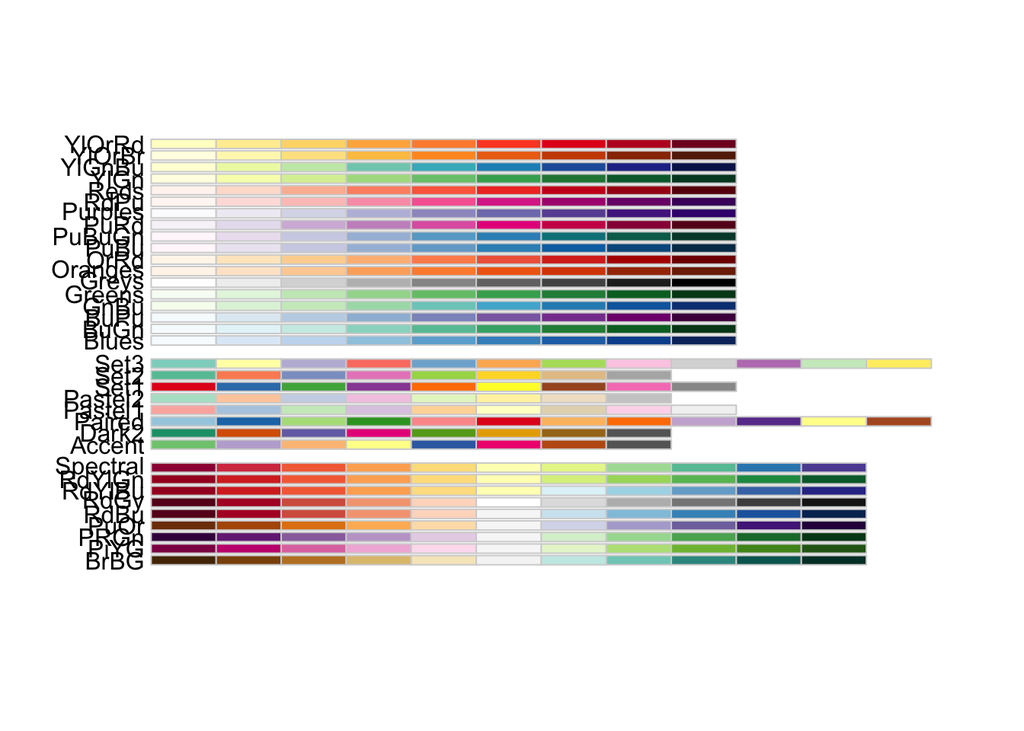

```r
display.brewer.all()
```

```r
brewer.pal.info
```

|  | maxcolors | category | colorblind |
| --- | --- | --- | --- |
| BrBG | 11 | div | TRUE |
| PiYG | 11 | div | TRUE |
| PRGn | 11 | div | TRUE |
| PuOr | 11 | div | TRUE |
| RdBu | 11 | div | TRUE |
| RdGy | 11 | div | FALSE |
| RdYlBu | 11 | div | TRUE |
| RdYlGn | 11 | div | FALSE |
| Spectral | 11 | div | FALSE |
| Accent | 8 | qual | FALSE |

[output cut: 25 more lines]

#Brewer Hex and Color palette BrBG can use:

```r
brewer.pal(n=11,name="BrBG")
```

```
##  [1] "#543005" "#8C510A" "#BF812D" "#DFC27D" "#F6E8C3" "#F5F5F5" "#C7EAE5"
##  [8] "#80CDC1" "#35978F" "#01665E" "#003C30"
```

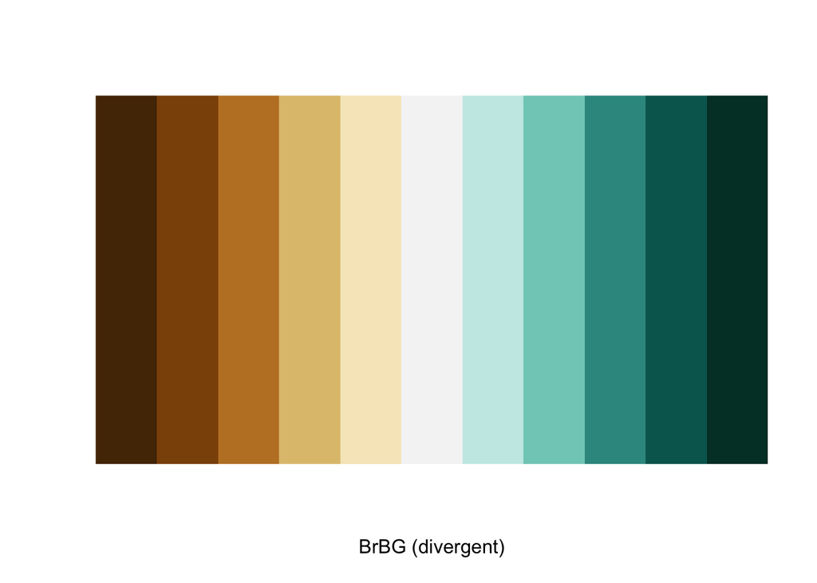

```r
display.brewer.pal(n=11,name="BrBG")
```

or can use `show_col` command instead

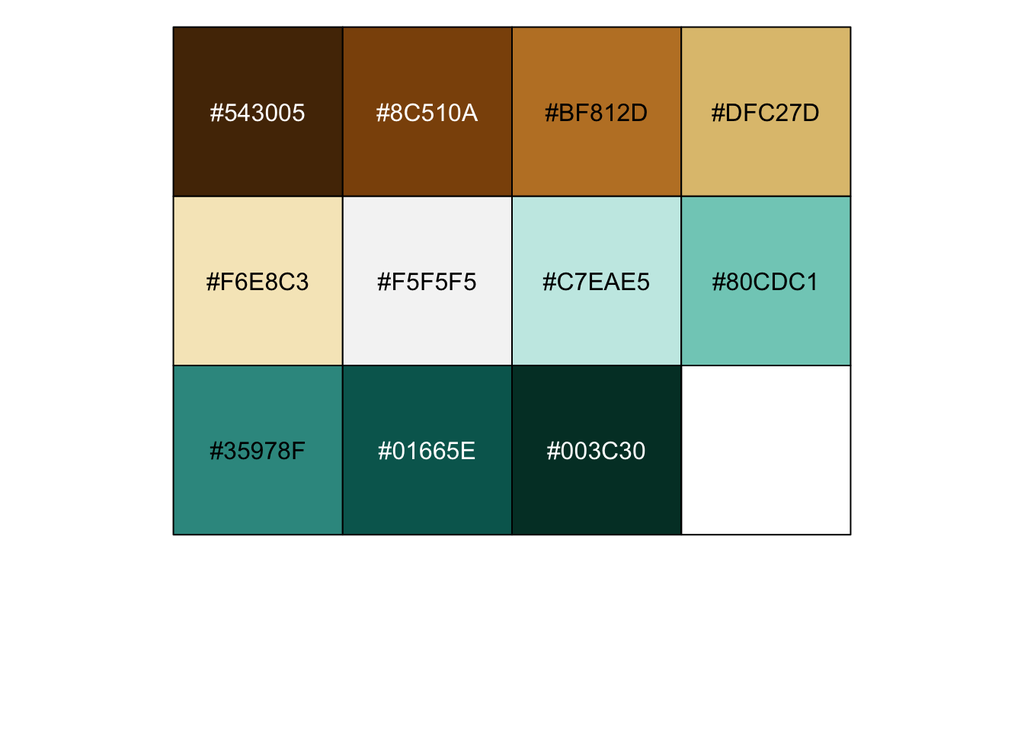

```r
show_col(brewer_pal(palette = "BrBG")(11))
```

#Wes Anderson Movie Color Themes

```r
wes_palettes
```

```
## $BottleRocket1
## [1] "#A42820" "#5F5647" "#9B110E" "#3F5151" "#4E2A1E" "#550307" "#0C1707"
##
## $BottleRocket2
## [1] "#FAD510" "#CB2314" "#273046" "#354823" "#1E1E1E"
##
## $Rushmore1
## [1] "#E1BD6D" "#EABE94" "#0B775E" "#35274A" "#F2300F"
##
## $Rushmore
## [1] "#E1BD6D" "#EABE94" "#0B775E" "#35274A" "#F2300F"
##
## $Royal1
## [1] "#899DA4" "#C93312" "#FAEFD1" "#DC863B"
##
## $Royal2
## [1] "#9A8822" "#F5CDB4" "#F8AFA8" "#FDDDA0" "#74A089"
##
## $Zissou1
## [1] "#3B9AB2" "#78B7C5" "#EBCC2A" "#E1AF00" "#F21A00"
##
## $Darjeeling1
## [1] "#FF0000" "#00A08A" "#F2AD00" "#F98400" "#5BBCD6"
##
## $Darjeeling2
## [1] "#ECCBAE" "#046C9A" "#D69C4E" "#ABDDDE" "#000000"
##
## $Chevalier1
## [1] "#446455" "#FDD262" "#D3DDDC" "#C7B19C"
##
## $FantasticFox1
## [1] "#DD8D29" "#E2D200" "#46ACC8" "#E58601" "#B40F20"
##
## $Moonrise1
## [1] "#F3DF6C" "#CEAB07" "#D5D5D3" "#24281A"
##
## $Moonrise2
## [1] "#798E87" "#C27D38" "#CCC591" "#29211F"
##
## $Moonrise3
## [1] "#85D4E3" "#F4B5BD" "#9C964A" "#CDC08C" "#FAD77B"
##
## $Cavalcanti1
## [1] "#D8B70A" "#02401B" "#A2A475" "#81A88D" "#972D15"
##
## $GrandBudapest1
## [1] "#F1BB7B" "#FD6467" "#5B1A18" "#D67236"
##
## $GrandBudapest2
## [1] "#E6A0C4" "#C6CDF7" "#D8A499" "#7294D4"
##
## $IsleofDogs1
## [1] "#9986A5" "#79402E" "#CCBA72" "#0F0D0E" "#D9D0D3" "#8D8680"
##
## $IsleofDogs2
## [1] "#EAD3BF" "#AA9486" "#B6854D" "#39312F" "#1C1718"
```

Bottle Rocket 1

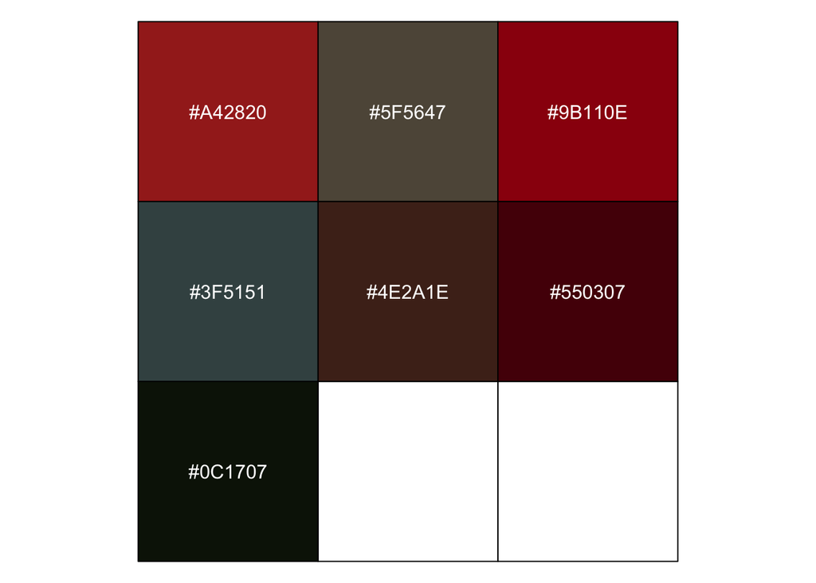

```r
show_col(wes_palettes$BottleRocket1,(7))
```

Bottle Rocket 2

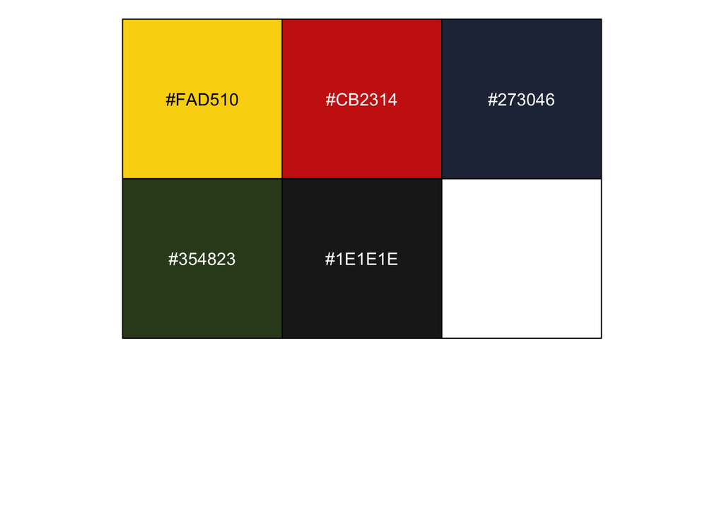

```r
show_col(wes_palettes$BottleRocket2)
```

Rushmore 1

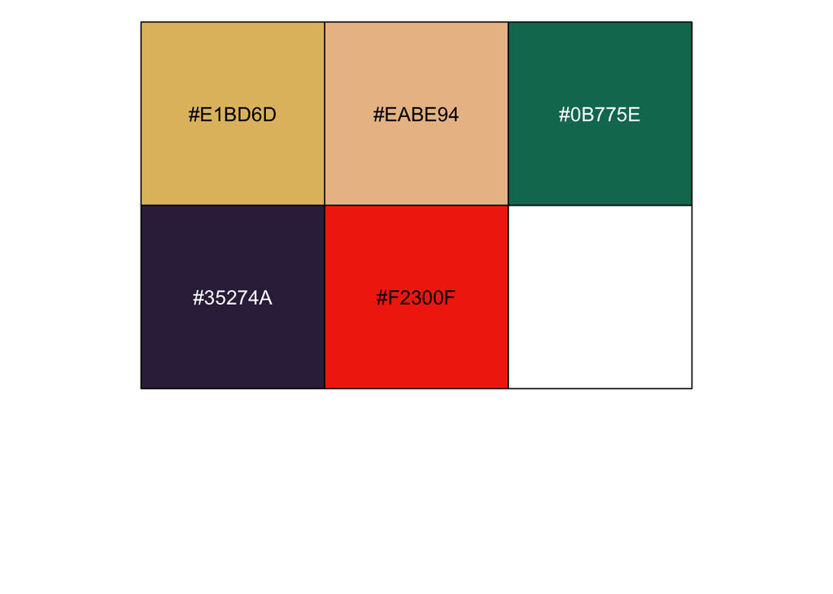

```r
show_col(wes_palettes$Rushmore1)
```

Royal 1

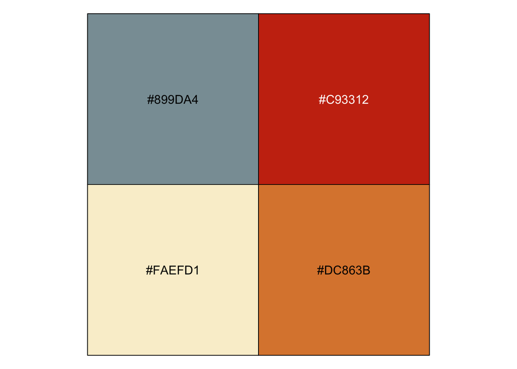

```r
show_col(wes_palettes$Royal1)
```

Royal 2

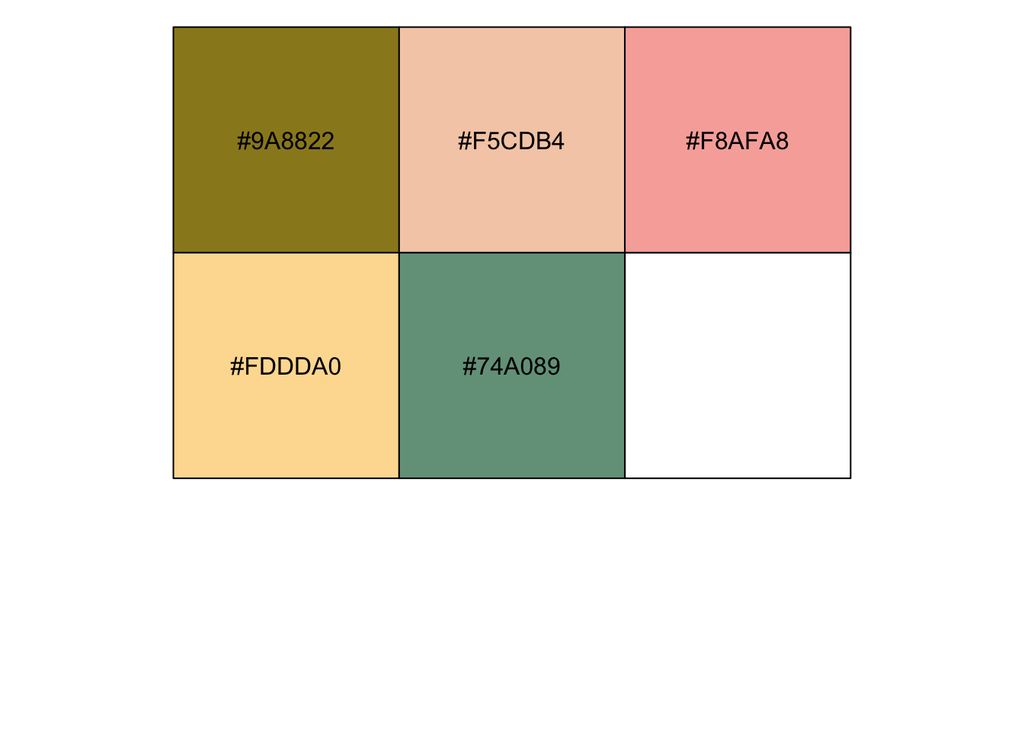

```r
show_col(wes_palettes$Royal2)
```

Zissou1

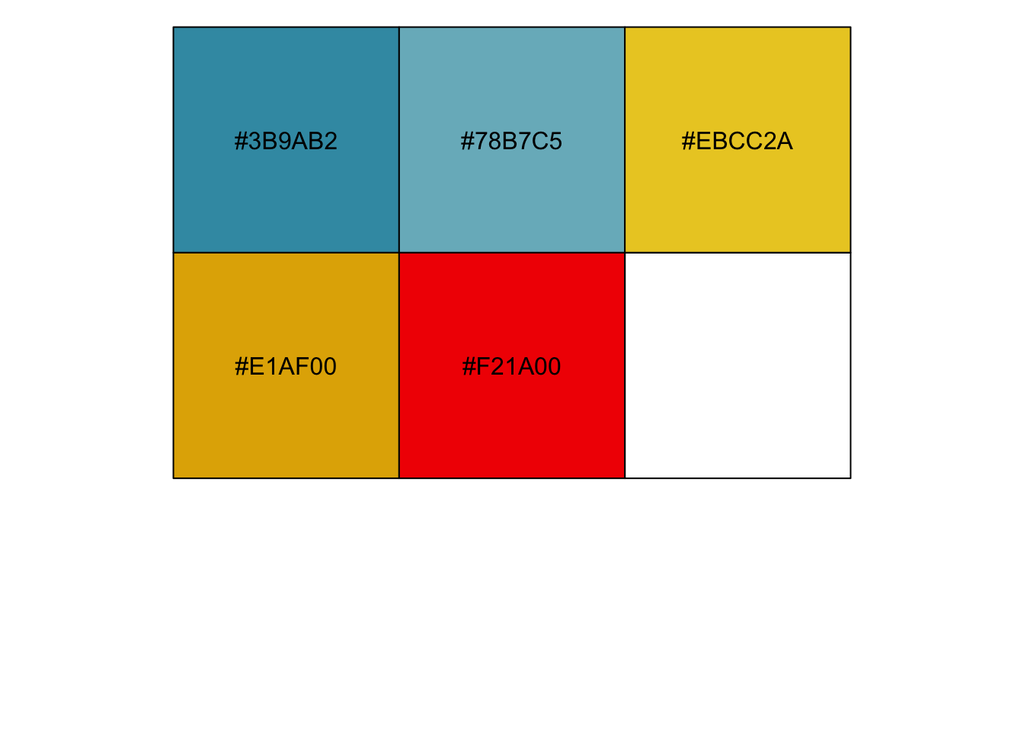

```r
show_col(wes_palettes$Zissou1)
```

Darjeeling1

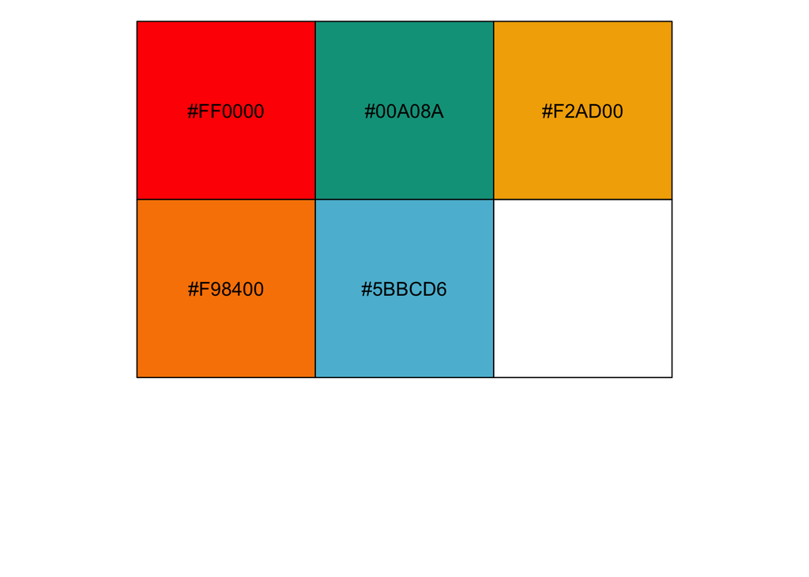

```r
show_col(wes_palettes$Darjeeling1)
```

Darjeeling2